# Spatial, and network models

Peter Ralph

12 March 2018 – Advanced Biological Statistics

# Spatial models

## A simple scenario

Suppose we have estimates of abundance of a soil microbe from a number of samples across our study area:

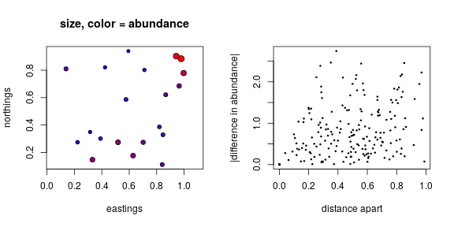

## The data

`(x,y)` : spatial coords; `z` : abundance

```r
xy
```

```
##            x         y        z
## 1  0.5766037 0.5863978 3.845720
## 2  0.2230729 0.2747410 3.571873
## 3  0.3318966 0.1476570 4.683332
## 4  0.7107246 0.8014103 3.410312
## 5  0.8194490 0.3864098 3.726504
## 6  0.4237206 0.8204507 3.356803
## 7  0.9635445 0.6849373 4.424564
## 8  0.9781304 0.8833893 5.795779
## 9  0.8405219 0.1119208 3.962872
## 10 0.9966112 0.7788340 5.155496
## 11 0.8659590 0.6210109 3.911921
## 12 0.7014217 0.2741515 4.235119
## 13 0.3904731 0.3014697 3.657133
## 14 0.3147697 0.3490438 3.342371
## 15 0.8459473 0.3291311 3.835436
## 16 0.1392785 0.8095039 4.035925
## 17 0.5181206 0.2744821 4.694328
## 18 0.5935508 0.9390949 3.054045
## 19 0.9424617 0.9022671 5.518488
## 20 0.6280196 0.1770531 4.617342
```

**Goals:**

1. (descriptive) What spatial scale does abundance vary over?
2. (predictive) What are the likely (range of) abundances at new locations?

# Spatial covariance

## Tobler’s First Law of Geography:

> Everything is related to everything else, but near things are more related than distant things.

*Modeler:* Great, covariance is a decreasing function of distance.

## A decreasing function of distance.

A convenient choice: the covariance between two points distance $d$ apart is
$$\begin{aligned}
\alpha^2 \exp\left(- \frac{1}{2}\left(\frac{d}{\rho}\right)^2 \right) .
\end{aligned}$$

- $\alpha$ controls the overall variance (amount of noise)
- $\rho$ is the spatial scale that covariance decays over

## In Stan

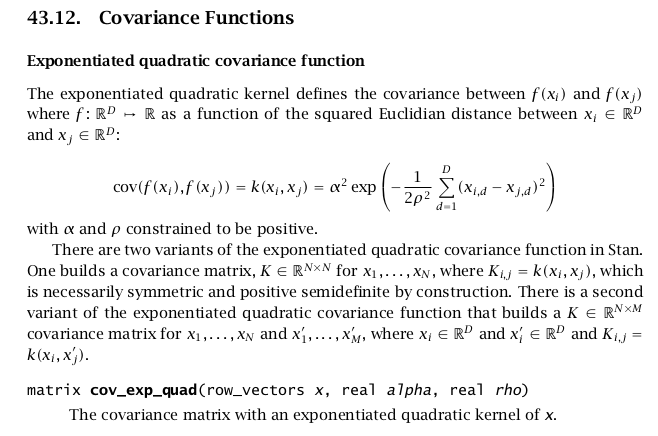

cov_exp_quad() documentation

Here’s an `R` function that takes a set of locations (`xy`), a variance scaling `alpha`, and a spatial scale `rho`:

```r
cov_exp_quad <- function (xy, alpha, rho) {
    # return the 'quadratic exponential' covariance matrix
    # for spatial positions xy
    dxy <- as.matrix(dist(xy))
    return( alpha^2 * exp( - (1/2) * dxy^2 / rho^2 ) )
}
```

**Challenge:** simulate spatially autocorrelated random Gaussian values, and plot them, in space. Pick parameters so you can tell they are autocorrelated.

*to color points by a continuous value:*

```
     colorRampPalette(c('blue', 'red'))(24)[cut(xy$z, breaks=24)]
```

## Simulation

```r
library(mvtnorm)
N <- 100
# spatial extent of order 1
xy <- data.frame(y=runif(N),
                 x=rnorm(N))
rho <- .25
alpha <- 1.0
# compute covariance matrix
K <- cov_exp_quad(xy, alpha, rho)
# simulate z's
xy$z <- as.vector(rmvnorm(1, mean=rep(0,N),
                          sigma=K))
```

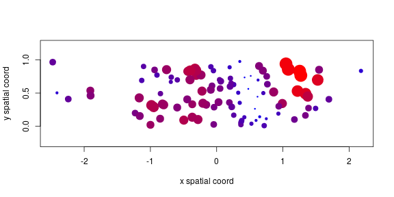

```r
plot(xy$x, xy$y, xlab='x spatial coord',
     ylab='y spatial coord', pch=20, asp=1,
     cex=as.numeric(cut(xy$z, breaks=10))/2,
     col=colorRampPalette(c('blue', 'red'))(24)[cut(xy$z, breaks=24)])
```

## Simulation number 2

```r
library(mvtnorm)
N <- 1000
# spatial extent of order 1
xy <- data.frame(x=runif(N),
                 y=rnorm(N))
rho <- .25
alpha <- 1.0
# compute covariance matrix
K <- cov_exp_quad(xy, alpha, rho)
# simulate z's
xy$z <- as.vector(rmvnorm(1, mean=rep(0,N),
                          sigma=K))
```

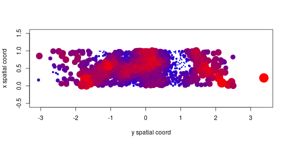

```r
plot(xy$y, xy$x, xlab='y spatial coord',
     ylab='x spatial coord', pch=20, asp=1,
     cex=as.numeric(cut(xy$z, breaks=10))/2,
     col=colorRampPalette(c('blue', 'red'))(24)[cut(xy$z, breaks=24)])
```

# Back to the data

## Goals

1. (descriptive) What spatial scale does abundance vary over?

   $\Rightarrow$ What is $\rho$?
2. (predictive) What are the likely (range of) abundances at new locations?

   $\Rightarrow$ Add unobserved abundances as *parameters*.

## A basic Stan block

```r
sp_block <- "
data {
    int N; // number of obs
    vector[2] xy[N]; // spatial pos
    vector[N] z;
}
parameters {
    real<lower=0> alpha;
    real<lower=0> rho;
}
model {
    matrix[N, N] K;
    K = cov_exp_quad(xy, alpha, rho);

    z ~ multi_normal(rep_vector(0.0, N), K);
    alpha ~ normal(0, 5);
    rho ~ normal(0, 5);
}
"
# check this compiles
sp_model <- stan_model(model_code=sp_block)
```

**Challenge:** we would like to estimate the abundance at the `k` locations `new_xy`. Add this feature to the Stan block.

```
data {
    int N; // number of obs
    vector[2] xy[N]; // spatial pos
    vector[N] z;
}
parameters {
    real<lower=0> alpha;
    real<lower=0> rho;
}
model {
    matrix[N, N] K;
    K = cov_exp_quad(xy, alpha, rho);

    z ~ multi_normal(rep_vector(0.0, N), K);
    alpha ~ normal(0, 5);
    rho ~ normal(0, 5);
}
```

## A solution

```r
sp_block <- "
data {
    int N; // number of obs
    vector[2] old_xy[N]; // spatial pos
    vector[N] old_z;
    int n;
    vector[2] new_xy[n]; // new locs
}
transformed data {
    vector[2] xy[N+n];
    xy[1:N] = old_xy;
    xy[(N+1):(N+n)] = new_xy;
    print(dims(old_z));
}
parameters {
    real<lower=0> alpha;
    real<lower=0> rho;
    vector[n] new_z;
    real<lower=0> delta;
    real mu;
}
model {
    matrix[N+n, N+n] K;
    vector[N+n] z;
    K = cov_exp_quad(xy, alpha, rho);
    for (k in 1:(N+n)) {
        K[k,k] += delta;
    }
    z[1:N] = old_z;
    z[(N+1):(N+n)] = new_z;
    z ~ multi_normal(rep_vector(mu, N+n), K);
    alpha ~ normal(0, 5);
    rho ~ normal(0, 5);
    delta ~ normal(0, 5);
    mu ~ normal(0, 5);
}
"

new_sp <- stan_model(model_code=sp_block)
```

## Simulate data

```r
library(mvtnorm)
N <- 20
xy <- data.frame(x=runif(N), y=runif(N))
dxy <- as.matrix(dist(xy))
ut <- upper.tri(dxy, diag=TRUE)
truth <- list(rho=.6,
              delta=.1,
              alpha=2.5,
              mu=5)
truth$covmat <- (truth$delta * diag(N)
                 + truth$alpha^2 * exp(-(dxy/truth$rho)^2))
xy$z <- as.vector(rmvnorm(1, mean=rep(truth$mu,N), sigma=truth$covmat))
```

## It runs.

```r
new_xy <- cbind(x=runif(5), y=runif(5))
sp_data <- list(N=nrow(xy),
                old_xy=cbind(xy$x, xy$y),
                old_z=xy$z,
                n=nrow(new_xy),
                new_xy=as.matrix(new_xy))

(sp_time <- system.time(
    sp_fit <- sampling(new_sp,
                       data=sp_data,
                       iter=1000,
                       chains=2,
                       control=list(adapt_delta=0.99,
                                    max_treedepth=12))))
```

[output not shown]

```
##    user  system elapsed
##   1.369   0.036   2.447
```

## Does it work?

```r
cbind(truth=truth[c("alpha", "rho", "delta", "mu")],
      rstan::summary(sp_fit, pars=c("alpha", "rho", "delta", "mu"))$summary)
```

```
##       truth mean      se_mean     sd        2.5%      25%       50%
## alpha 2.5   4.234435  0.08918686  2.023869  1.77594   2.775801  3.721438
## rho   0.6   0.6926219 0.01211368  0.2500757 0.3555691 0.5261485 0.6432864
## delta 0.1   0.2805626 0.007569845 0.1598728 0.0942439 0.1729031 0.2409412
## mu    5     5.330636  0.09851299  2.568532  0.1735635 3.843481  5.406842
##       75%       97.5%     n_eff    Rhat
## alpha 5.101349  9.161582  514.9476 1.009623
## rho   0.8055962 1.368224  426.1778 1.009142
## delta 0.3386181 0.7397388 446.0414 1.004646
## mu    6.868921  9.874479  679.8029 1.000725
```

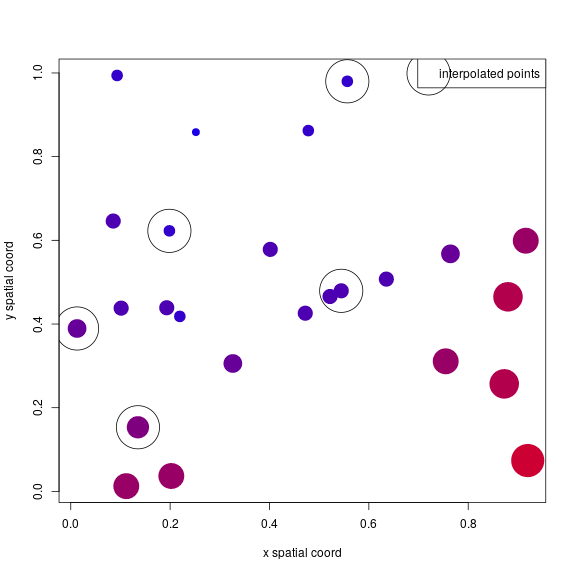

## Conclusions

1. (descriptive) What spatial scale does abundance vary over?

   Values are correlated over distances of order $\rho=0.6926219$ units of distance.
2. (predictive) What are the likely (range of) abundances at new locations?

   These are

```
##                   x         y     mean        sd
## new_z[1] 0.01268409 0.3892949 4.120024 0.7242546
## new_z[2] 0.13522095 0.1532280 5.420720 0.6137691
## new_z[3] 0.55666986 0.9800330 2.687552 0.8721023
## new_z[4] 0.54442795 0.4793665 3.824439 0.6073334
## new_z[5] 0.19853665 0.6226803 2.494086 0.6191298
```

# Network models

## What we’ve just done

- **Model:** the data are *multivariate Normal*,
- with *nearby* locations have *more correlated* values.
- To do this, we set the entries of the covariance matrix equal to a decreasing function of *distance*;
- then, we could *estimate* values at unobserved locations.

We could do the *same thing* in a **network** model, calculating “nearby” and “distance” with the network.

## Example

A network:

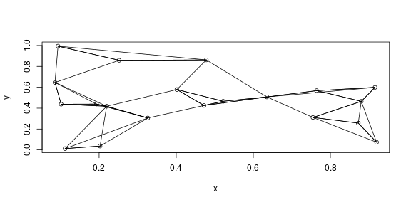

```r
A <- (dxy < rowQuantiles(dxy, probs=0.2))
diag(A) <- FALSE

plot(xy[,1:2])
segments(x0=xy[row(A)[A],1], x1=xy[col(A)[A],1],
         y0=xy[row(A)[A],2], y1=xy[col(A)[A],2])
```

Here is the *adjacency matrix* of the network:

```r
A
```

```
##        1     2     3     4     5     6     7     8     9    10    11    12
## 1  FALSE FALSE  TRUE FALSE FALSE FALSE FALSE FALSE  TRUE FALSE  TRUE FALSE
## 2  FALSE FALSE FALSE FALSE FALSE FALSE FALSE FALSE FALSE FALSE FALSE  TRUE
## 3   TRUE FALSE FALSE FALSE FALSE FALSE FALSE FALSE FALSE FALSE FALSE  TRUE
## 4  FALSE FALSE FALSE FALSE  TRUE FALSE FALSE FALSE FALSE FALSE FALSE FALSE
## 5  FALSE FALSE FALSE  TRUE FALSE FALSE FALSE  TRUE FALSE FALSE FALSE FALSE
## 6  FALSE FALSE FALSE FALSE FALSE FALSE FALSE FALSE FALSE FALSE  TRUE FALSE
## 7  FALSE FALSE FALSE FALSE FALSE FALSE FALSE FALSE FALSE FALSE FALSE FALSE
## 8  FALSE FALSE FALSE  TRUE  TRUE FALSE FALSE FALSE FALSE FALSE FALSE FALSE
## 9   TRUE FALSE  TRUE FALSE FALSE FALSE FALSE FALSE FALSE FALSE  TRUE FALSE
## 10 FALSE FALSE FALSE FALSE FALSE FALSE FALSE FALSE FALSE FALSE FALSE FALSE
## 11 FALSE FALSE FALSE FALSE FALSE  TRUE FALSE FALSE FALSE FALSE FALSE FALSE
## 12 FALSE  TRUE FALSE FALSE FALSE FALSE FALSE FALSE FALSE FALSE FALSE FALSE
## 13 FALSE  TRUE FALSE FALSE FALSE FALSE FALSE FALSE FALSE FALSE FALSE FALSE
## 14 FALSE FALSE FALSE  TRUE FALSE FALSE FALSE FALSE FALSE  TRUE FALSE FALSE
```

[output cut: 27 more lines]

Our **model** has random variates at each node of the network, correlated with neighbors.

Suppose that

1. Every node has mean $\mu$ and variance $\alpha^2$.
2. Neighboring nodes have covariance $\alpha^2 \times \rho$.

Then, the covariance matrix is

```r
truth <- list(
              alpha = 2.5,
              rho = 0.6)
truth$covmat <- truth$alpha^2 * (diag(nrow(A)) + truth$rho * A)
```

```r
xy$z <- as.vector(rmvnorm(1, mean=rep(truth$mu,N), sigma=truth$covmat))
```

```
## Error in rmvnorm(1, mean = rep(truth$mu, N), sigma = truth$covmat): sigma must be a symmetric matrix
```

## Analysis options

1. Suppose the network is *unknown*, and infer it.
2. Suppose the network is *known*, and use it as a *smoothing prior* to help infer noisy or unobserved values at some of the nodes.

# Summary

## We can now

1. Simulate autocorrelated values on a landscape.
2. Parameterize and fit a spatial, multivariate Normal model.
3. Interpolate a noisy landscape to unobserved locations.